# Statistical Inference

EC 325: Econometrics

Prof. Caraher

Colby College

Oct 27, 2026

# From Estimates to Evidence

## Where We’ve Been

- We know how to **estimate** $\hat{\beta}_j$ using OLS
- We know the Gauss-Markov assumptions guarantee OLS is **BLUE**
- But every estimate comes from *one sample* — a different sample gives a different $\hat{\beta}_j$

**The Big Question Today**

How do we know if our estimate reflects a **real** relationship — or just **noise** from sampling? We do this by asking whether our estimate would be **surprising** if there were no real relationship

## The Roadmap

First, we turn Unit 5’s variance formula into something we can compute: the **standard error**.

Then we build five tools for answering the big question:

1. **The sampling distribution** — what would happen across many samples?
2. **Hypothesis testing** — is there evidence of a real effect?
3. **P-values** — how strong is that evidence?
4. **Confidence intervals** — what’s the plausible range for $\beta_j$?
5. **F-tests** — do several variables matter jointly?

# From Variance to Standard Error

## Step 1: Variance → Standard Deviation

From Unit 5, under GM 1–5, the sampling distribution of $\hat{\beta}_j$ has variance

$$Var(\hat{\beta}_j) = \frac{\sigma^2}{SST_j(1 - R_j^2)}$$

Variance is in **squared units**: $\hat{\beta}_{hp}$ is in MPG per horsepower, so $Var(\hat{\beta}_{hp})$ is in (MPG per hp)$^2$. This is not very meaningful!

Let’s take the square root instead to get **standard deviation**:

$$sd(\hat{\beta}_j) = \sqrt{Var(\hat{\beta}_j)} = \frac{\sigma}{\sqrt{SST_j(1 - R_j^2)}}$$

- Now, same units as $\hat{\beta}_j$
- But we have one big problem: **$sd(\hat{\beta}_j)$ depends on $\sigma$, the standard deviation of the *population* errors.**
- So, we need a way to **estimate** $\sigma^2$ and $\sigma$

## Step 2: From $\sigma$ to $\hat{\sigma}$

- To do so, we bring back GM5, $Var(\mu_i) = \sigma^2$. Plugging in the definition of variance and using GM4 ($E[\mu_i] = 0$):

$$\sigma^2 = Var(\mu_i) = E\big[(\mu_i - E[\mu_i])^2\big] = E\big[\mu_i^2\big] \quad \text{: the } \textbf{average squared error}$$

1. **Average the squared errors:** We need to compute the average for our sample $\frac{1}{n}\sum_{i} \mu_i^2$. But we can’t see $\mu_i$ (it needs the true $\beta$’s)
2. **Use the residuals instead:** $\frac{1}{n}\sum_{i} \hat{\mu}_i^2 = \frac{SSR}{n}$. But it’s **too small**: OLS minimizes $\sum \hat{\mu}_i^2$
3. **Divide by the degrees of freedom:** only $n - k - 1$ residuals are free to vary, where $n$ is the number of observations, and $k$ is the number of RHS variables

$$\hat{\sigma}^2 = \frac{SSR}{n - k - 1}, \qquad E[\hat{\sigma}^2] = \sigma^2 \;\; \text{(unbiased)}$$

- $\hat{\sigma} = \sqrt{\hat{\sigma}^2}$ is R’s **“Residual standard error”**: 2.593 MPG for `mpg ~ hp + wt`

## Step 3: Standard Deviation → Standard Error

Swap $\hat{\sigma}$ in for the unknown $\sigma$:

$$sd(\hat{\beta}_j) = \frac{\sigma}{\sqrt{SST_j(1 - R_j^2)}} \quad \Longrightarrow \quad se(\hat{\beta}_j) = \frac{\hat{\sigma}}{\sqrt{SST_j(1 - R_j^2)}}$$

**The Standard Error Is an *Estimate***

$se(\hat{\beta}_j)$ is our one sample’s best guess at $sd(\hat{\beta}_j)$. A different sample would give a slightly different standard error, since the residuals $\hat{\mu}_i$ also vary sample-to-sample.

## The Standard Error Is an Estimate: A Simulation

**What the Standard Error Is Trying to Capture**

We only ever get **one** estimate $\hat{\beta}_j$. The standard error tries to answer: *if we could redraw the sample over and over, how far would $\hat{\beta}_j$ typically land from the true $\beta_j$?* That spread is $sd(\hat{\beta}_j)$, and $se(\hat{\beta}_j)$ is our best guess at it using just the one sample we have.

To see it, re-run `mtcars` 5,000 times (same 32 cars, new random errors) and plot the results:

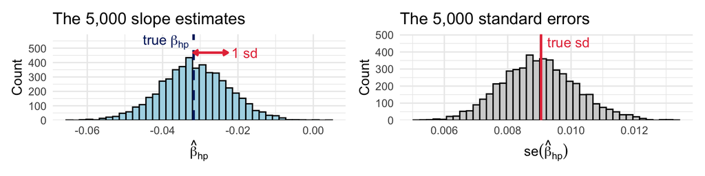

- **Left:** if we *could* observe 5,000 samples, the standard deviation of the estimates would be 0.0090. That spread **is** $sd(\hat{\beta}_{hp})$ (the formula gives 0.0091), but in real life we never see it
- **Right:** each sample’s $se$ is its *guess* at that spread: **near** the truth, but not on it (middle 90%: 0.0071 to 0.0110)

## Computing the Standard Error in R

- In R, the standard error is reported for each coefficient next to its estimate

```r
reg <- lm(mpg ~ hp + wt, data = mtcars)

summary(reg)
```

```
Call:
lm(formula = mpg ~ hp + wt, data = mtcars)

Residuals:
   Min     1Q Median     3Q    Max
-3.941 -1.600 -0.182  1.050  5.854

Coefficients:
            Estimate Std. Error t value   Pr(>|t|)
(Intercept) 37.22727    1.59879  23.285    < 2e-16 ***
hp          -0.03177    0.00903  -3.519    0.00145 **
wt          -3.87783    0.63273  -6.129 0.00000112 ***
---
Signif. codes:  0 '***' 0.001 '**' 0.01 '*' 0.05 '.' 0.1 ' ' 1

Residual standard error: 2.593 on 29 degrees of freedom
Multiple R-squared:  0.8268,    Adjusted R-squared:  0.8148
F-statistic: 69.21 on 2 and 29 DF,  p-value: 9.109e-12
```

## Computing the Standard Error by Hand

- Let’s check our formula works!

```r
reg <- lm(mpg ~ hp + wt, data = mtcars)
n <- nobs(reg)
k <- 2

sigma_hat <- sqrt(sum(resid(reg)^2) / (n - k - 1))        # residual standard error
sst_hp    <- sum((mtcars$hp - mean(mtcars$hp))^2)          # total variation in hp
r2_hp     <- summary(lm(hp ~ wt, data = mtcars))$r.squared # share of hp shared with wt

se_hp <- sigma_hat / sqrt(sst_hp * (1 - r2_hp))
c(by_hand = se_hp, from_summary = summary(reg)$coefficients["hp", "Std. Error"])
```

```
     by_hand from_summary
  0.00902971   0.00902971
```

# The Sampling Distribution

## Center, Spread, Shape

- Recall: we need a way to figure out how “surprising” our specific estimate is
- To do so, we need to know its full **sampling distribution**
  - **Sampling distribution:** the distribution of $\hat{\beta}_j$ across all the samples we *could* have drawn from the population
- To figure out the sampling distribution, we need to know 3 things (some we already do!)

|  | Question | What we know |
| --- | --- | --- |
| **1. Center** | Where is it centered? | ✅ $E[\hat{\beta}_j] = \beta_j$ (unbiasedness, GM 1–4) |
| **2. Spread** | How much does it vary? | ✅ $sd(\hat{\beta}_j)$, estimated by $se(\hat{\beta}_j)$: the `Std. Error` column |
| **3. Shape** | What distribution does it follow? | ❓ Not yet |

## The Missing Piece: Shape

We know the center and the spread — but that’s not enough.

Lots of distributions can have the same mean and standard deviation but look **very different**:

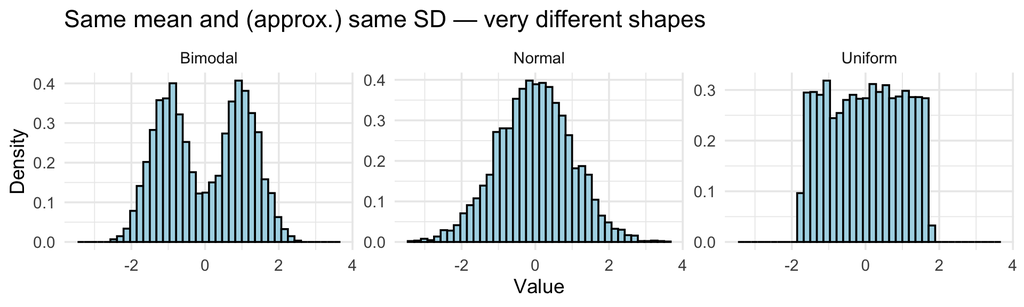

To know what’s “surprising” vs. “expected” — to do hypothesis tests and build confidence intervals — we need to know the **shape**.

## The Central Limit Theorem Gives Us the Shape

**Central Limit Theorem (CLT):** sums and averages of many independent random pieces are approximately **normal** in large samples, **whatever** the distribution of the individual pieces.

**Why does this apply to $\hat{\beta}_j$?** Because under the hood it is just a weighted sum of the errors!

So in large samples ($\overset{a}{\sim}$ means “approximately distributed as”):

$$\hat{\beta}_j \overset{a}{\sim} Normal\left(\beta_j, \; Var(\hat{\beta}_j)\right) \qquad \text{equivalently} \qquad \frac{\hat{\beta}_j - \beta_j}{se(\hat{\beta}_j)} \overset{a}{\sim} Normal(0, 1)$$

- This means that as long as $n$ is sufficiently large, the sampling distribution of $\hat{\beta}_j$ **will always be (approximately) normally distributed**

## Simulation: Normal vs. Skewed Errors

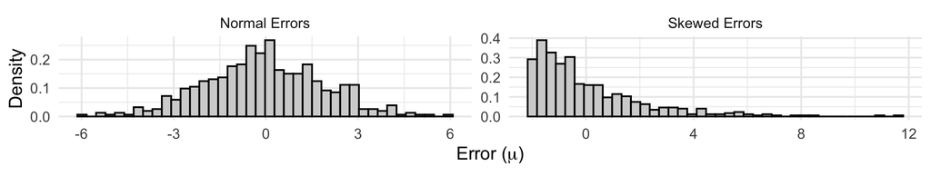

Symmetric errors vs. heavily right-skewed errors (like wages). Is $\hat{\beta}_1$ still normal?

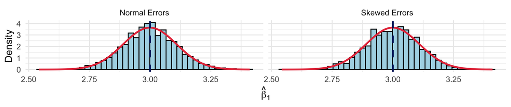

The normal curve fits **both**, even with $n = 50$: the **CLT** at work.

# Hypothesis Testing

## The Logic of the Test

Now that we know the center, spread, and shape of $\hat{\beta}_j$’s sampling distribution, we can test whether **our one estimate** is “surprising” given a baseline value for $\beta_j$. We call this a **hypothesis test**!

We usually want to know **does $x_j$ actually affect $y$?** So, let’s use $\beta_j = 0$ as the baseline for our test!

We formalize this as testing the *Null Hypothesis* against an *Alternative Hypothesis*:

- **Null hypothesis:** $H_0: \beta_j = 0$ — no effect
- **Alternative:** $H_1: \beta_j \neq 0$ — there is an effect

How does the test work?

**The Strategy**

1. **Assume** $H_0$ is true and construct a hypothetical sampling distribution around that null hypothesis value ($\beta_j = 0$, usually)
2. Ask: “Would my estimate be surprising under this assumption?”
3. If yes → reject $H_0$ (evidence of a real effect)

**Caution:** rejecting $H_0$ is evidence that $\beta_j \neq 0$. But $\beta_j$ is a causal effect only if GM4 holds (no omitted confounders, Unit 5). A significant result does not fix omitted variable bias.

## Step 1: Under the Null, We Know What to Expect

If $H_0: \beta_j = 0$ is true, we can construct the **entire sampling distribution** of $\hat{\beta}_j$, so we know what the “no effect” distribution of $\hat{\beta}_j$ looks like:

- **Center:** $E[\hat{\beta}_j] = 0$ (unbiasedness + the null)
- **Spread:** measured by $se(\hat{\beta}_j)$ (from the data)
- **Shape:** approximately normal (CLT)

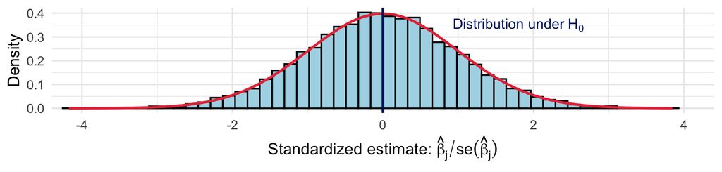

Most values cluster near zero; values far from zero are **rare**. **Question:** Does our estimate look like it belongs here, or does it seem unlikely based on the sampling distribution?

## Step 2: The t-Statistic

We need to **standardize** our estimate so we can place it on that distribution:

$$t_{\hat{\beta}_j} = \frac{\hat{\beta}_j}{se(\hat{\beta}_j)}$$

- This tells us: **how many standard errors away from zero** is our estimate?

| $t$-stat | Interpretation |
| --- | --- |
| $t = 0.5$ | Half a standard error from zero — could easily be noise |
| $t = 2.0$ | Two standard errors away — unusual under $H_0$ |
| $t = 4.0$ | Four standard errors away — very unlikely to be noise |

- Same sign as $\hat{\beta}_j$ (since $se > 0$); bigger $|t|$ = stronger evidence against $H_0$

## Step 3: How Far Is “Too Far”?

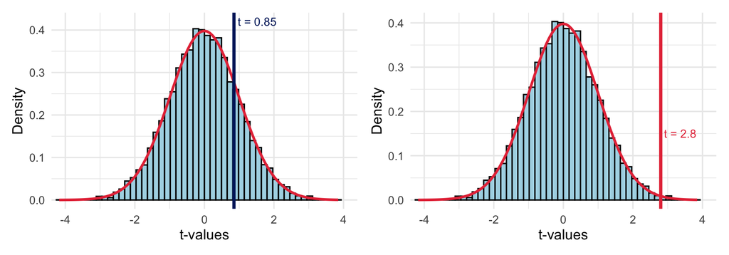

- $t = 0.85$: well within the distribution of likely estimates — no reason to doubt $H_0$
- $t = 2.8$: out in the tail — this would be **rare** if $H_0$ were true

## A Decision Rule: Type I Error and $\alpha$

$t = 0.85$ feels “fine” and $t = 2.8$ feels “surprising,” but where exactly do we draw the line?

- Even when $H_0$ is true, sampling variability sometimes produces a large $t$-stat **by chance**
- Rejecting $H_0$ when it’s actually true is a **Type I error** (a “false positive”)
- Set the bar **too low** → lots of false alarms. Set it **too high** → we miss real effects

We can’t eliminate this risk, but we can **control** it:

- The **significance level** $\alpha$ is our tolerance for a Type I error: $\alpha = 0.05$ accepts a 5% chance of false rejection; $\alpha = 0.01$ only 1%
- The **critical value** $c$ is the threshold: reject if $|t| > c$

**Where Do Critical Values Come From?**

1. **The source:** the $t_{n-k-1}$ distribution, which describes our $t$-statistic when $H_0$ is true. (It’s the normal with slightly fatter tails, because $se$ is estimated.) $c$ is the cutoff that leaves $\alpha/2$ in each tail
2. **What determines them:** the significance level $\alpha$ (smaller $\alpha$ → larger $c$) and the degrees of freedom $n - k - 1$ (fewer df → fatter tails → larger $c$). For $\alpha = 0.05$ with large $n$, $c \approx 1.96$
3. **In R:** `qt(1 - alpha/2, df = n - k - 1)`. For example, `qt(0.975, df = 29)` gives 2.05 and `qt(0.975, df = 1000)` gives 1.96

## Critical Values and Rejection Regions

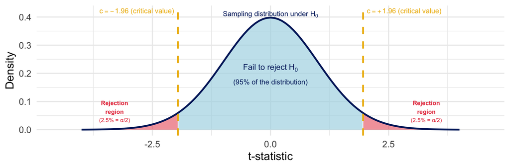

- The **red areas** combined = $\alpha = 5\%$ — the probability of a Type I error (rejecting when $H_0$ is true)
- The **dashed lines** at $\pm 1.96$ are the **critical values** — our decision boundary
- **Decision rule:** reject $H_0$ if $|t| > 1.96$
- **Rule of 2:** in large samples, an estimate is significant at 5% if it’s more than **twice** its standard error, $|\hat{\beta}_j| > 2 \times se(\hat{\beta}_j)$. Handy when scanning regression output

## Testing Other Values

$H_0: \beta_j = 0$ is the default, but we can test **any** value $a_j$ by centering the $t$-statistic there:

$$t = \frac{\hat{\beta}_j - a_j}{se(\hat{\beta}_j)}$$

**Example:** Is health care a “luxury good”? Suppose the estimated income elasticity of health spending is $\hat{\beta}_1 = 0.82$ with $se = 0.07$. Test $H_0: \beta_1 = 1$:

$$t = \frac{0.82 - 1}{0.07} = -2.57 \quad \Rightarrow \quad |t| > 1.96, \text{ so reject } \beta_1 = 1$$

The elasticity is significantly **below** 1: health care looks like a necessity, not a luxury.

- Same critical values, same decision rule: only the center moves
- **One-sided tests** ($H_1: \beta_j > a_j$) put all 5% in one tail, so the critical value is `qt(0.95, df)` $\approx 1.65$. Choose the direction **before** seeing the data

## The t-Test, Step by Step

Every t-test follows the same six steps:

1. **State the hypotheses:** $H_0: \beta_j = a_j$ vs. $H_1: \beta_j \neq a_j$. Usually $a_j = 0$ (“no effect”)
2. **Choose the significance level** $\alpha$ *before* looking at the results. Usually $\alpha = 0.05$
3. **Compute the t-statistic:** $t = \dfrac{\hat{\beta}_j - a_j}{se(\hat{\beta}_j)}$, with $\hat{\beta}_j$ and $se(\hat{\beta}_j)$ from the regression output. Usually, we are testing if an estimate is statistically different from **zero** (i.e., no effect), so $a_j = 0$
4. **Find the critical value** $c$ from the $t_{n-k-1}$ distribution: `qt(1 - alpha/2, df = n - k - 1)`. About 1.96 when $n$ is large
5. **Decide:** reject $H_0$ if $|t| > c$. Otherwise, **fail to reject** $H_0$ (never “accept”)
6. **Conclude in words:** is $x_j$ statistically significant at the $\alpha$ level? What does $\hat{\beta}_j$ mean in the units of $x_j$ and $y$?

## t-Test Example 1: Horsepower and Fuel Economy

Back to `lm(mpg ~ hp + wt, data = mtcars)`: $\hat{\beta}_{hp} = -0.03177$ and $se(\hat{\beta}_{hp}) = 0.00903$, with $n = 32$ cars and $k = 2$

1. **Hypotheses:** $H_0: \beta_{hp} = 0$ vs. $H_1: \beta_{hp} \neq 0$
2. **Significance level:** $\alpha = 0.05$
3. **t-statistic:** $t = \dfrac{-0.03177 - 0}{0.00903} = -3.52$
4. **Critical value:** $df = 32 - 2 - 1 = 29$, so $c$ = `qt(0.975, df = 29)` = 2.05. Larger than 1.96, because with only 32 cars the $t$ distribution has fatter tails
5. **Decision:** $|t| = 3.52 > 2.05$, so **reject $H_0$**
6. **Conclusion:** holding weight constant, each extra horsepower is associated with 0.032 fewer MPG (about 3.2 MPG per 100 hp). This is statistically significant at the 5% level

## t-Test Example 2: ACT Scores and College GPA

141 college students in `wooldridge::gpa1`: college GPA (`colGPA`), high school GPA (`hsGPA`), and ACT score (`ACT`)

1. **Hypotheses:** $H_0: \beta_{ACT} = 0$ vs. $H_1: \beta_{ACT} \neq 0$, holding `hsGPA` constant
2. **Significance level:** $\alpha = 0.05$

Steps 3–5 in R:

```r
library(wooldridge)
reg_gpa <- lm(colGPA ~ hsGPA + ACT, data = gpa1)
b_act   <- coef(reg_gpa)[["ACT"]]
se_act  <- summary(reg_gpa)$coefficients["ACT", "Std. Error"]
t_act   <- (b_act - 0) / se_act                        # Step 3
c_05    <- qt(1 - 0.05/2, df = df.residual(reg_gpa))   # Step 4: df = n - k - 1
round(c(estimate = b_act, se = se_act, t = t_act, crit = c_05), 4)
abs(t_act) > c_05                                      # Step 5: reject?
```

```
estimate       se        t     crit
  0.0094   0.0108   0.8746   1.9773
[1] FALSE
```

6. **Conclusion:** holding high school GPA constant, ACT is **not** statistically significant at 5% (0.009 GPA points per ACT point). On its own, it is ($t = 2.49$): most of what ACT tells us, high school GPA already does

## t-Test Example 3: A Close Call

Are CEOs paid for performance? `lm(salary ~ sales + roe, data = ceosal1)` for 209 CEOs: `salary` is in $1,000s, `sales` in $ millions, and `roe` is the firm’s return on equity (%). We get $\hat{\beta}_{roe} = 19.63$ and $se(\hat{\beta}_{roe}) = 11.08$.

1. **Hypotheses:** $H_0: \beta_{roe} = 0$ vs. $H_1: \beta_{roe} \neq 0$
2. **Significance level:** $\alpha = 0.05$
3. **t-statistic:** $t = \dfrac{19.63 - 0}{11.08} = 1.77$
4. **Critical value:** $df = 209 - 2 - 1 = 206$, so $c$ = `qt(0.975, df = 206)` = 1.97
5. **Decision:** $|t| = 1.77 < 1.97$, so **fail to reject $H_0$** at 5%

Had we chosen $\alpha = 0.10$ in step 2, $c$ = `qt(0.95, df = 206)` = 1.65 and we would **reject**. Same data, same $t$: the verdict depends on $\alpha$, which is why we choose it *before* looking.

- Example 2 ($t = 0.87$) and Example 3 ($t = 1.77$) both “fail to reject” at 5%, but the evidence is very different
- “Reject” or “fail to reject” hides **how close** the call was. That is what **p-values** measure

# P-Values

## Beyond “Reject” or “Fail to Reject”

The t-test with a fixed critical value gives a **binary** answer: significant or not.

But it doesn’t tell us **how strongly** we reject — was it a narrow rejection or a knockout?

The **p-value** answers this:

**Definition**

The p-value is the **probability of seeing a t-statistic as extreme as ours** (or more extreme), *if the null hypothesis were true*.

Equivalently: the **smallest significance level** at which we would reject $H_0$.

## Visualizing the P-Value

Think back to the rejection region plot. Instead of asking “is my t-stat past the critical value?”, the p-value asks: **how much of the distribution is more extreme than my t-stat?**

Suppose we observe $t = 2.3$. What fraction of the distribution under $H_0$ lies beyond $\pm 2.3$?

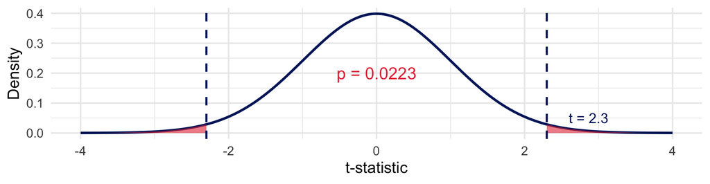

The red area = p-value = 0.0223. If $H_0$ were true, only a 2.2% chance of a $t$-statistic at least this far from zero.

**In R:** `2 * pt(-abs(t), df = n - k - 1)`. Here, `2 * pt(-2.3, df = 250)` gives 0.0223.

## Interpreting P-Values

- **p = 0.03:** If $\beta_j = 0$, only a 3% chance of an estimate at least this far from zero. That’s unlikely — reject $H_0$ at 5%.
- **p = 0.35:** If $\beta_j = 0$, a 35% chance of an estimate at least this far from zero. Not unusual at all — fail to reject.

**Decision rule:** Reject $H_0$ if $p < \alpha$ (your chosen significance level)

**Common Misconception**

The p-value is **NOT** the probability that $H_0$ is true!

It’s the probability of **seeing data this extreme** if $H_0$ *were* true. Big difference.

## Statistical vs. Practical Significance

**Remember: What Are We Actually Testing?**

All a significance test asks is whether $\hat{\beta}_j$ is **statistically different from zero**. It asks the question: is our estimate picking up a **real relationship** between $x$ and $y$, or could it just be **noise** from the particular sample we happened to draw? The test says nothing about whether that relationship is **big** or **meaningful**.

**Key Distinction**

A **statistically significant** result ($p < 0.05$) is not necessarily **practically important**.

- Example: with a large enough sample, even **tiny** effects become significant
- Suppose a drug lowers blood pressure by 0.1 mmHg ($p = 0.001$)
  - Statistically significant? ✅
  - Clinically meaningful? ❌
- **Always** look at the **magnitude** of $\hat{\beta}_j$, not just the p-value!

## Do P-Values Work?

Simulate a world where $H_0$ is **true**: the same 32 cars, but horsepower has **no effect** on MPG, $\beta_{hp} = 0$. In each of 5,000 samples, run `lm(mpg ~ hp + wt)` and test $H_0: \beta_{hp} = 0$ at $\alpha = 0.05$.

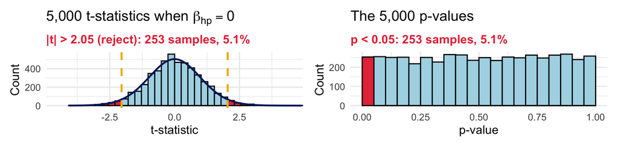

- **Type I error:** $H_0$ is true every time, yet we reject it in 253 of 5,000 samples (5.1%): the 5% that $\alpha = 0.05$ promised
- **The p-values:** spread **evenly** from 0 to 1 when $H_0$ is true, so $p < \alpha$ happens $\alpha$ of the time: $p < 0.05$ in the **same** 253 samples, $p < 0.10$ in 10.2%
- **One p-value, checked:** `2 * pt(-2.3, df = 29)` = 0.029, and 3.0% of the simulated $t$’s land beyond $\pm 2.3$

# Applying It All in R

## Example: Housing Prices

Now we have the full toolkit — t-statistics, p-values, and the logic connecting them. Let’s see how all of these show up in R’s regression output.

```r
set.seed(2025)
n <- 500
housing_data <- tibble(
  sqft = runif(n, 800, 3500),
  bedrooms = sample(1:5, n, replace = TRUE),
  age = sample(0:60, n, replace = TRUE),
  sale_price = 50000 + 100 * sqft + 8000 * bedrooms -
               500 * age + rnorm(n, 0, 40000)
)

# Three specifications: bivariate → add a control → full model
reg1 <- lm(sale_price ~ sqft, data = housing_data)
reg2 <- lm(sale_price ~ sqft + bedrooms, data = housing_data)
reg3 <- lm(sale_price ~ sqft + bedrooms + age, data = housing_data)
```

## Reading the Output

```r
summary(reg3)
```

```
Call:
lm(formula = sale_price ~ sqft + bedrooms + age, data = housing_data)

Residuals:
    Min      1Q  Median      3Q     Max
-113743  -30040    -224   29373  115625

Coefficients:
            Estimate Std. Error t value Pr(>|t|)
(Intercept) 53861.26    7029.09   7.663 9.65e-14 ***
sqft           97.04       2.33  41.658  < 2e-16 ***
bedrooms     8667.91    1302.16   6.657 7.45e-11 ***
age          -514.75     103.90  -4.954 9.98e-07 ***
---
Signif. codes:  0 '***' 0.001 '**' 0.01 '*' 0.05 '.' 0.1 ' ' 1

Residual standard error: 41210 on 496 degrees of freedom
Multiple R-squared:  0.7837,    Adjusted R-squared:  0.7824
F-statistic: 599.1 on 3 and 496 DF,  p-value: < 2.2e-16
```

## Decoding `summary()`

The **Coefficients table** has four columns:

| Column | What it shows |
| --- | --- |
| `Estimate` | $\hat{\beta}_j$ — the point estimate |
| `Std. Error` | $se(\hat{\beta}_j)$ — how precise the estimate is |
| `t value` | $\hat{\beta}_j / se(\hat{\beta}_j)$ — the t-statistic |
| `Pr(>\|t\|)` | The p-value |

**Significance stars:**

| Stars | Meaning |
| --- | --- |
| (none) | $p \geq 0.10$ |
| `.` | $p < 0.10$ |
| `*` | $p < 0.05$ |
| `**` | $p < 0.01$ |
| `***` | $p < 0.001$ |

## Reading a Regression Table

In published research (and in your problem sets!), you won’t see raw `summary()` output. Instead, results are presented in a **regression table** using packages like `modelsummary`:

|  | (1) | (2) | (3) |
| --- | --- | --- | --- |
| Constant | 64627.1*** | 40665.2*** | 53861.3*** |
|  | (5699.9) | (6657.1) | (7029.1) |
| Square Feet | 96.7*** | 96.4*** | 97.0*** |
|  | (2.5) | (2.4) | (2.3) |
| Bedrooms |  | 8466.8*** | 8667.9*** |
|  |  | (1332.0) | (1302.2) |
| House Age |  |  | -514.7*** |
|  |  |  | (103.9) |
| Num.Obs. | 500 | 500 | 500 |
| R2 | 0.755 | 0.773 | 0.784 |
| R2 Adj. | 0.754 | 0.772 | 0.782 |

* p < 0.1, ** p < 0.05, *** p < 0.01  
Standard errors in parentheses.

## Anatomy of a Regression Table

**Rows:** Each row is one regressor ($x_j$). The top number is $\hat{\beta}_j$; the number in parentheses below it is $se(\hat{\beta}_j)$.

**Columns:** Each column is a different regression specification. Here, (1) is bivariate, (2) adds bedrooms, and (3) adds house age. Placing them side-by-side lets you see how coefficients change as controls are added — this is how researchers show their results are (or aren’t) robust.

**Stars:** Indicate statistical significance — but the thresholds vary by paper! Always check the **notes at the bottom** for the convention (e.g., `* p < 0.1, ** p < 0.05, *** p < 0.01`).

**Bottom rows:** Summary statistics — typically $N$, $R^2$, adjusted $R^2$.

**Common Mistakes When Reading Tables**

- The parentheses contain **standard errors** — not t-statistics, not confidence intervals!
- Stars don’t tell you about practical significance — always look at the **magnitude** of $\hat{\beta}_j$
- Authors usually put regressions in the same table for a reason — understanding why is important for understanding the argument of the author!

## Practice: Fully Interpret a Regression Table

Dependent variable: birth weight (ounces)

|  | (1) | (2) |
| --- | --- | --- |
| Constant | 120.627*** | 113.736*** |
|  | (0.607) | (3.695) |
| Cigarettes per day | -0.620*** | -0.606*** |
|  | (0.108) | (0.110) |
| Birth order |  | 1.765*** |
|  |  | (0.660) |
| Mother's educ. (years) |  | -0.276 |
|  |  | (0.314) |
| Father's educ. (years) |  | 0.580** |
|  |  | (0.274) |
| Num.Obs. | 1191 | 1191 |
| R2 | 0.027 | 0.037 |

* p < 0.1, ** p < 0.05, *** p < 0.01  
Standard errors in parentheses.

Births from the 1988 National Health Interview Survey (`bwght`). Cigarettes are smoked per day during pregnancy.

**Worked example: column (1)**

- **Cigarettes:** each additional cigarette per day is associated with a **0.62 oz lower** birth weight. Statistically significant at the **1%** level
- **Constant:** babies of mothers who don’t smoke have a predicted birth weight of **120.6 oz**

**🖥️ Your turn: column (2)**

For **each** coefficient, state the effect in the **correct units** (holding the others constant) and whether it’s significant at **1%, 5%, 10%**, or not at all

## Practice: Answers for Column (2)

**Model answer:** Holding birth order and parents’ education constant, each additional cigarette smoked per day during pregnancy is associated with a **0.61 oz lower** birth weight. This is statistically significant at the **1%** level.

- **Birth order:** each later birth (e.g., 2nd vs. 1st child) → **1.77 oz higher**. Significant at **1%**
- **Mother’s educ.:** each extra year → 0.28 oz lower. **Not** significant, even at 10% (p = 0.38)
- **Father’s educ.:** each extra year → **0.58 oz higher**. Significant at **5%**, not 1% (p = 0.035)
- **Constant:** 113.7 oz is the prediction when every regressor is 0 (birth order 0, parents with no schooling). Birth order starts at 1, so it has no useful interpretation here
- **Compare to (1):** the cigarette effect barely moves (-0.62 → -0.61) once we add the controls

# Confidence Intervals

## From Point Estimates to Ranges

- While t-tests and p-values are useful for determining if your estimate is likely or not under a null hypothesis, they don’t tell you much about the actual possible values $\beta_j$ can take
- A **confidence interval** gives a **range of plausible values** for $\beta_j$:

$$CI = \hat{\beta}_j \pm c \cdot se(\hat{\beta}_j)$$

For a 95% CI, $c$ is the 5% two-sided critical value, `qt(0.975, df = n - k - 1)`. With large $n$, $c \approx 1.96$:

$$CI_{95\%} = \hat{\beta}_j \pm 1.96 \cdot se(\hat{\beta}_j)$$

## Computing CIs in R

**🖥️ Try it yourself!**

```r
# By hand, with the t critical value (df = n - k - 1)
b1    <- coef(reg3)["sqft"]
se1   <- summary(reg3)$coefficients["sqft", "Std. Error"]
c_95  <- qt(0.975, df = df.residual(reg3))
lower <- b1 - c_95 * se1
upper <- b1 + c_95 * se1
cat("Manual 95% CI: [", round(lower, 4), ",", round(upper, 4), "]\n")
```

```
Manual 95% CI: [ 92.4659 , 101.6197 ]
```

Or use R’s `confint()` function:

```r
# confint() computes CIs directly
# First arg = model, second = which coefficient, level = confidence level
confint(reg3, "sqft", level = 0.95)
```

```
        2.5 %   97.5 %
sqft 92.46586 101.6197
```

## What Does “95% Confident” Mean?

If we drew many samples and built a 95% CI from each, about **95%** of the intervals would contain the true $\beta_j$. The “95%” describes the **procedure**: any one interval either contains $\beta_j$ or it doesn’t, and we can’t tell which.

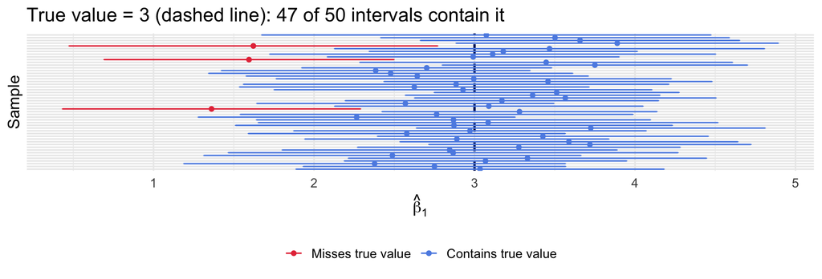

## The CI ↔︎ Hypothesis Test Connection

There’s a direct link between CIs and hypothesis testing:

| If the 95% CI… | Then at the 5% level… |
| --- | --- |
| **Excludes** zero | We **reject** $H_0: \beta_j = 0$ |
| **Includes** zero | We **fail to reject** $H_0: \beta_j = 0$ |

This makes CIs a handy visual shortcut — just check if zero is inside the interval!

**Three Tools, One Answer**

$|t| > 1.96$ ⟺ $p < 0.05$ ⟺ 95% CI excludes zero

They always agree, but each answers a different question: Is my estimate large relative to the noise ($t$)? How surprising would it be if $H_0$ were true ($p$)? What values of $\beta_j$ are plausible (CI)?

## Fail to Reject ≠ “No Effect”

Failing to reject $H_0: \beta_j = 0$ does **not necessarily** show the effect is zero. Our data may just be too noisy to detect it (a **Type II error**: missing a real effect).

The CI tells you which case you’re in. Two studies of a prenatal program’s effect on birth weight (grams), neither statistically significant:

| Study | Estimate | 95% CI | What we learn |
| --- | --- | --- | --- |
| A | 20 | [−180, 220] | **Inconclusive:** consistent with large harm, no effect, or a large benefit |
| B | 5 | [−15, 25] | **Informative null:** small or near-zero effect |

- Say “we fail to reject $H_0$,” never “we accept $H_0$”
- Report the CI so readers can tell which kind of insignificant result you have — large and uncertain, or a precise zero!

# F-Tests: Testing Multiple Hypotheses

## The Problem with Multiple t-Tests

So far, all our tools test **one coefficient at a time**.

But what if we want to ask: “Do `bedrooms` and `age` **jointly** matter for house prices?”

You might think: just look at each t-test separately!

**Two Problems with That Approach**

1. **No restrictions on other parameters:** A t-test on $\beta_2$ puts no restrictions on $\beta_3$. Both could be individually insignificant yet *jointly* explain a lot.
2. **Multiple comparisons:** Running many tests at 5% means you’ll reject some true nulls by chance. With 20 tests of true nulls, expect about 1 false rejection!

## The F-Test Solution

The **F-test** tests multiple coefficients **simultaneously**: one joint question, one test, one 5% chance of a false rejection.

Do `bedrooms` and `age` *jointly* matter? $\quad H_0: \beta_2 = \beta_3 = 0 \qquad H_1: \text{at least one} \neq 0$

Compare the model **with** and **without** them:

- **Unrestricted** (full model): $\; price = \beta_0 + \beta_1(sqft) + \beta_2(bedrooms) + \beta_3(age) + \mu$
- **Restricted** (imposes $H_0$): $\; price = \beta_0 + \beta_1(sqft) + \mu$

If `bedrooms` and `age` actually matter, **dropping them should make the fit much worse**. The F-statistic measures *how much worse*.

## The F-Statistic Formula

$$F = \frac{(R^2_{UR} - R^2_R)\,/\,q}{(1 - R^2_{UR})\,/\,df_{UR}}$$

| Symbol | Meaning |
| --- | --- |
| $R^2_{UR}$ | $R^2$ from the **unrestricted** (full) model |
| $R^2_R$ | $R^2$ from the **restricted** model (the $H_0$ variables dropped) |
| $q$ | Number of restrictions (variables dropped) |
| $df_{UR}$ | Degrees of freedom in the unrestricted model ($n - k - 1$) |

- **Numerator:** how much $R^2$ *improves* when we add the variables back, per restriction
- **Denominator:** how much variation the full model *still* leaves unexplained, per degree of freedom (the noise)
- A large $F$ means the variables explain far more than noise alone would. Adding variables never lowers $R^2$, so $F \geq 0$

## F-Test: Computing It by Hand

```r
reg_unrestricted <- lm(sale_price ~ sqft + bedrooms + age, data = housing_data)
reg_restricted   <- lm(sale_price ~ sqft, data = housing_data)   # imposes H0

r2_ur <- summary(reg_unrestricted)$r.squared
r2_r  <- summary(reg_restricted)$r.squared
q     <- 2                                   # number of restrictions
df_ur <- df.residual(reg_unrestricted)       # n - k - 1

f_stat <- ((r2_ur - r2_r) / q) / ((1 - r2_ur) / df_ur)
f_crit <- qf(0.95, df1 = q, df2 = df_ur)     # 5% critical value
round(c(R2_R = r2_r, R2_UR = r2_ur, F = f_stat, F_crit = f_crit), 3)
```

```
  R2_R  R2_UR      F F_crit
 0.755  0.784 33.431  3.014
```

**Where Does the F Critical Value Come From?**

1. **The source:** the **F distribution**, which describes the $F$-statistic when $H_0$ is true. It’s right-skewed and never negative (dropping variables can only lower $R^2$), and averages about 1 when the dropped variables don’t matter. So we reject only in the **right tail**: $F > F_{crit}$
2. **What determines it:** the significance level $\alpha$ and **two** degrees of freedom: $q$ (number of restrictions) and $df_{UR} = n - k - 1$
3. **In R:** `qf(1 - alpha, df1 = q, df2 = df_ur)`. Here, `qf(0.95, 2, 496)` gives 3.01
- Our $F = 33.43$ is far above 3.01: **reject $H_0$**. `bedrooms` and `age` jointly matter

## The Easy Way: `anova()`

In practice, use R’s `anova()` function — pass it the restricted model first, then the unrestricted:

```r
anova(reg_restricted, reg_unrestricted)
```

```
Analysis of Variance Table

Model 1: sale_price ~ sqft
Model 2: sale_price ~ sqft + bedrooms + age
  Res.Df          RSS Df    Sum of Sq      F    Pr(>F)
1    498 955884067193
2    496 842335853904  2 113548213289 33.431 2.398e-14 ***
---
Signif. codes:  0 '***' 0.001 '**' 0.01 '*' 0.05 '.' 0.1 ' ' 1
```

- Same $F = 33.43$ we computed by hand, plus its p-value
- If we reject $H_0$, the variables are **jointly statistically significant**, but we **can’t** tell *which* one matters
- Failing to reject does **not** show the coefficients are zero. Whether to keep a control depends on whether it’s a **confounder** (Unit 5), not on its p-value

## Reading the `anova()` Output

Row 1 is the restricted model, row 2 the unrestricted. Each column is a piece of the formula (B = billion):

| Column | Here | What it is | In the formula |
| --- | --- | --- | --- |
| `Res.Df` | 498, 496 | Residual df, $n - k - 1$ | Row 2 is $df_{UR}$ |
| `RSS` | 955.9B, 842.3B | SSR: variation left unexplained | $RSS / SST = 1 - R^2$ |
| `Df` | 2 | Drop in `Res.Df` = variables dropped | $q$ |
| `Sum of Sq` | 113.5B | Drop in `RSS` = extra variation explained | $\text{Sum of Sq} / SST = R^2_{UR} - R^2_R$ |
| `F` | 33.43 | The F-statistic | $F$ |
| `Pr(>F)` | 2.4e-14 | p-value: chance of an $F$ this big if $H_0$ true | Reject $H_0$ if $p < \alpha$ |

**Why RSS Instead of $R^2$?**

Both models explain the same $y$, so they share one $SST$ (here 3,894.5B). Divide by it: 842.3B / 3,894.5B = 0.216 $= 1 - R^2_{UR}$, and 113.5B / 3,894.5B = 0.029 $= R^2_{UR} - R^2_R$. $SST$ cancels in the ratio, so it’s the same $F$.

## F-Test Example: Parents’ Education

Back to column (2) of the birth weight table: do mother’s and father’s education **jointly** matter? $\;H_0: \beta_{motheduc} = \beta_{fatheduc} = 0$

```r
# Unrestricted = column (2); the restricted model drops both education variables
m_restricted <- lm(bwght ~ cigs + parity, data = bw_cc)
bw_f <- anova(m_restricted, m_mult)
bw_f
```

```
Analysis of Variance Table

Model 1: bwght ~ cigs + parity
Model 2: bwght ~ cigs + parity + motheduc + fatheduc
  Res.Df    RSS Df Sum of Sq      F  Pr(>F)
1   1188 466846
2   1186 464961  2    1885.1 2.4043 0.09077 .
---
Signif. codes:  0 '***' 0.001 '**' 0.01 '*' 0.05 '.' 0.1 ' ' 1
```

- $F = 2.40$, $p = 0.091$: **fail to reject** $H_0$ at 5%, but reject at 10%
- Father’s education **alone** is significant at 5% ($p = 0.035$), but **jointly** the two are not

**Watch the Sample**

`lm()` silently drops rows with missing values. Fit the restricted model on all of `bwght` and it uses 1,388 births instead of 1,191, so `anova()` stops with *“models were not all fitted to the same size of dataset.”* Both models must use the **same observations**.

# Wrapping Up

## Key Takeaways

**What You Should Remember**

1. **Standard error:** $\hat{\beta}_j$ varies across samples; $se(\hat{\beta}_j)$ is our one-sample *estimate* of how much
2. **Hypothesis test:** Compare your t-stat to the $t_{n-k-1}$ critical value ($\approx 1.96$ in large samples, the Rule of 2)
3. **P-value:** If $H_0$ were true, the probability of an estimate at least as extreme as ours. Small $p$ = strong evidence against $H_0$
4. **Confidence interval:** A range of plausible values for $\beta_j$. Failing to reject is not evidence of no effect: check how wide the CI is
5. **F-test:** Tests whether multiple coefficients are *jointly* significant — use `anova()` in R
6. **Statistical ≠ practical significance** — always look at the *magnitude*, not just the stars!

EC325 | Unit 6 | Statistical Inference